# Using `Spatial*` and `Raster` Data in R [Practical]

2022-09-02

# **The Set-up**

## *Learning objectives.*

1. Load, create, manipulate, and save `Spatial*` object using `R`.
2. Load, create, manipulate/extract, and save `Raster*` object using `R`.
3. Use map algebra to create and manipulate `Raster*` object using `R`.
4. Extract information from `Spatial*` and `Raster*`object using R.

## *Before you start*

The practical will be run using *RStudio cloud* to avoid individual machine troubleshooting. This means you **need** to have an account for *RStudio cloud*.

However, remember to have [`R`](https://cran.r-project.org) and [R-studio](http://www.rstudio.com/) in your/room computer so you can work on the project after class.

**You should have also** 1. Read chapters 2, 3, and 4 Bivand et al. Applied Spatial Data Analysis with R. Springer, 2013. 2. Done the Tutorial for this week.

## *The way it’s going to be run*

In this 3h practical you will to implement what you have learned in the class about `Spatial*` and `Raster*`objects and how to Load, create, manipulate, and save these in `R`.

You will be building and **R-Markdown** document during the class. **R-Markdown** documents allows you to combine your code, its results, and your prose commentary into a single document. If you manage to produce a document your code works. The resulting file (a html) is what you will hand-in at the end of the practical.

**This is a 3h practical** and you will use all the time. Also try to write your own `R`-code and run it **DO NOT COPY THE CODE OF SOMEONE ELSE**. Writing your code and figuring out why it does not work is the best way to understand the dynamics of the `R` language and the tasks you are doing. Also, you have an excellent teaching assistant resource - ask him and/or me all the questions you have.

The final document will have for classes of boxes

The text in the blue filled box marked as **Your task** states what you need to do

```r
#
# The code in the window marked like this shows where you need to write your code
#
```

The text in the green filled box marked as **Question** phrases a question.

Here you will place the answer to the **question**.

# **Obtaining environmental data for the Biowide dataset**

## *1. Load the Data*

**Your task:**

Load the data in *occurrence.csv*. The file is the folder associated to the project to the session - see the files tab in your R-studio session.. For this:

- Use `read.csv` to load the file - The file is comma-separated
- Save the object as `DK.Biodiv`.

```r
# Step 1. Read the file and save it as an object named `DK.Biodiv`
DK.Biodiv <-  read.csv('Data/occurrence.csv')
```

## *2. What is in the Table?*

**Your task:**

Based on the data stored in the object `DK.Biodiv`, write code to answer the flowing questions:

- Which groups (phylum) where sampled in the dataset?

```r
# Step 1. Which groups where sampled in the dataset?
unique(DK.Biodiv$phylum)
```

```
##  [1] "Arthropoda"    "Ascomycota"    "Basidiomycota" "Bryophyta"
##  [5] "Hepatophyta"   "Magnoliophyta" "Mollusca"      "Pinophyta"
##  [9] "Pteridophyta"  "Nematoda"      ""              "Zygomycota"
## [13] "Glomeromycota"
```

**Your task:**

Based on the data stored in the object `DK.Biodiv`, write code to answer the flowing questions:

- How many observations where recorded for each group (phylum)?

```r
# Step 1. How many observations where recorded for each group (phylum)?
tapply(DK.Biodiv$scientificName, DK.Biodiv$phylum, function(x){length(x)})
```

```
##                  Arthropoda    Ascomycota Basidiomycota     Bryophyta
##             4         16916          3019          7467          2031
## Glomeromycota   Hepatophyta Magnoliophyta      Mollusca      Nematoda
##            11           317          5266           970             6
##     Pinophyta  Pteridophyta    Zygomycota
##           110           200             6
```

```r
#
```

**Your task:**

Based on the data stored in the object `DK.Biodiv`, write code to answer the flowing questions:

- How many species where recorded for each group (phylum)?
- How many observations are in the `DK.Biodiv` data set?

```r
#Step 1. How many species where recorded for each group (phylum)?
tapply(X = DK.Biodiv$scientificName,
       INDEX = DK.Biodiv$phylum,
       FUN = function(x){length(unique(x))})
```

```
##                  Arthropoda    Ascomycota Basidiomycota     Bryophyta
##             3          2411           557          1441           199
## Glomeromycota   Hepatophyta Magnoliophyta      Mollusca      Nematoda
##             3            55           680            77             3
##     Pinophyta  Pteridophyta    Zygomycota
##            13            20             2
```

```r
#Step 2. How many observations where recorded for each group (phylum)?
tapply(X = DK.Biodiv$scientificName,
       INDEX = DK.Biodiv$phylum,
       FUN = function(x){length(x)})
```

```
##                  Arthropoda    Ascomycota Basidiomycota     Bryophyta
##             4         16916          3019          7467          2031
## Glomeromycota   Hepatophyta Magnoliophyta      Mollusca      Nematoda
##            11           317          5266           970             6
##     Pinophyta  Pteridophyta    Zygomycota
##           110           200             6
```

**Question:**

- What is the Difference between the number of observations and the number of species per groups?

**Observations** is a count of the number of the number of individuals recorded regardless of the species identity. **Number of species** indicate the number of species recorded for a group, without considering the number of recorded individuals of each species.

**Your task:**

Based on the data stored in the object `DK.Biodiv`, estimate the avenge number of species per sampled site of the groups *Magnoliophyta* and *Pinophyta*. For this, you will:

- Add a new column to `DK.Biodiv` named *siteID* that define the unique locations by combining the `Lat` & `Lon` data. Use the function `paste()` or `paste0()` for this.
- Count the number of species per site for *Magnoliophyta*. Store the result in an object named `Rich.Magnoliophyta`.
- Count the number of species per site for *Pinophyta*. Store the result in an object named `Rich.Pinophyta`.
- Estimate the average number of species per site using the data in `Rich.Magnoliophyta` `Rich.Pinophyta`.

```r
# Avenge number of species per sampled site of the groups *Magnoliophyta* and *Pinophyta*?

# Step-1 Define the unique Locations based on Lat-Lon data - add it as a column to the data.frame
DK.Biodiv$siteID <- paste0(DK.Biodiv$decimalLatitude,"-",DK.Biodiv$decimalLongitude)

# Step 2 Count the number of species per site
Rich.Magnoliophyta <- tapply(X = DK.Biodiv[DK.Biodiv$phylum=="Magnoliophyta","scientificName"],
                             INDEX = DK.Biodiv[DK.Biodiv$phylum=="Magnoliophyta","siteID"],
                             FUN = function(x){length(unique(x))})
# Step 3 Count the number of species per site
Rich.Pinophyta <- tapply(X = DK.Biodiv[DK.Biodiv$phylum=="Pinophyta","scientificName"],
                         INDEX = DK.Biodiv[DK.Biodiv$phylum=="Pinophyta","siteID"],
                         FUN = function(x){length(unique(x))})

# Step 4 Estimate the average No of species Per site
mean(Rich.Magnoliophyta) # Average for Magnoliophyta
```

```
## [1] 40.50769
```

```r
mean(Rich.Pinophyta) # Average for Pinophyta
```

```
## [1] 1.964286
```

**Your task:**

Based on the data stored in the object `DK.Biodiv`, you will:

- Estimate the 95%-confidence interval in the number of species per sampled site of the groups *Magnoliophyta* and *Pinophyta* using the `quantile()` function.

```r
# 95%-confidence interval in the  number of species per sampled site of the groups *Magnoliophyta* and *Pinophyta*?

# Step 1 Estimate the 95%-confidence interval No of species Per site - using quantile
quantile(x = Rich.Magnoliophyta,
         probs = c(0.025,0.975)) # 95%-CI for Magnoliophyta
```

```
##  2.5% 97.5%
##  10.0 103.1
```

```r
quantile(x = Rich.Pinophyta,
         probs = c(0.025,0.975)) # 95%-CI for Pinophyta
```

```
##  2.5% 97.5%
## 1.000 5.625
```

**Your task:**

Based on the data stored in the object `DK.Biodiv`, you will:

- Estimate the 95%-confidence interval in the number of species per sampled site of the groups *Magnoliophyta* and *Pinophyta* using a using a normal approximation.

```r
# 95%-confidence interval in the  number of species per sampled site of the groups *Magnoliophyta* and *Pinophyta*?

# Step 1 Estimate the 95%-confidence interval No of species Per site - using a normal approximation
## 95%-CI for Magnoliophyta
round(c(mean(Rich.Magnoliophyta)-(qnorm(0.975)*(sd(Rich.Magnoliophyta)/sqrt(length(Rich.Magnoliophyta)))),
mean(Rich.Magnoliophyta)+(qnorm(0.975)*(sd(Rich.Magnoliophyta)/sqrt(length(Rich.Magnoliophyta))))),1)
```

```
## [1] 36.2 44.8
```

```r
## 95%-CI for Pinophyta
round(c(mean(Rich.Pinophyta)-(qnorm(0.975)*(sd(Rich.Pinophyta)/sqrt(length(Rich.Pinophyta)))),
mean(Rich.Pinophyta)+(qnorm(0.975)*(sd(Rich.Pinophyta)/sqrt(length(Rich.Pinophyta))))),1)
```

```
## [1] 1.6 2.3
```

**Question:**

- What is the Difference between using the `quantile` function and a normal approximation to estimate 95%-Confidence intervals?

The **`quantile()``** function estimate the *sample* percentiles - the value at which a given percentage of the observations fall below. The normal approximation, assumes that the data is normally distributed, and uses this assumption to define the 95%-CI.

**Your task:**

Based on the data stored in the object `DK.Biodiv`, write code to answer the flowing questions:

- Count the number of species per site per group using the function `tapply()`.
- Plot the box-plot of the **Log_10* of the number of species per site sites for all evaluated groups.

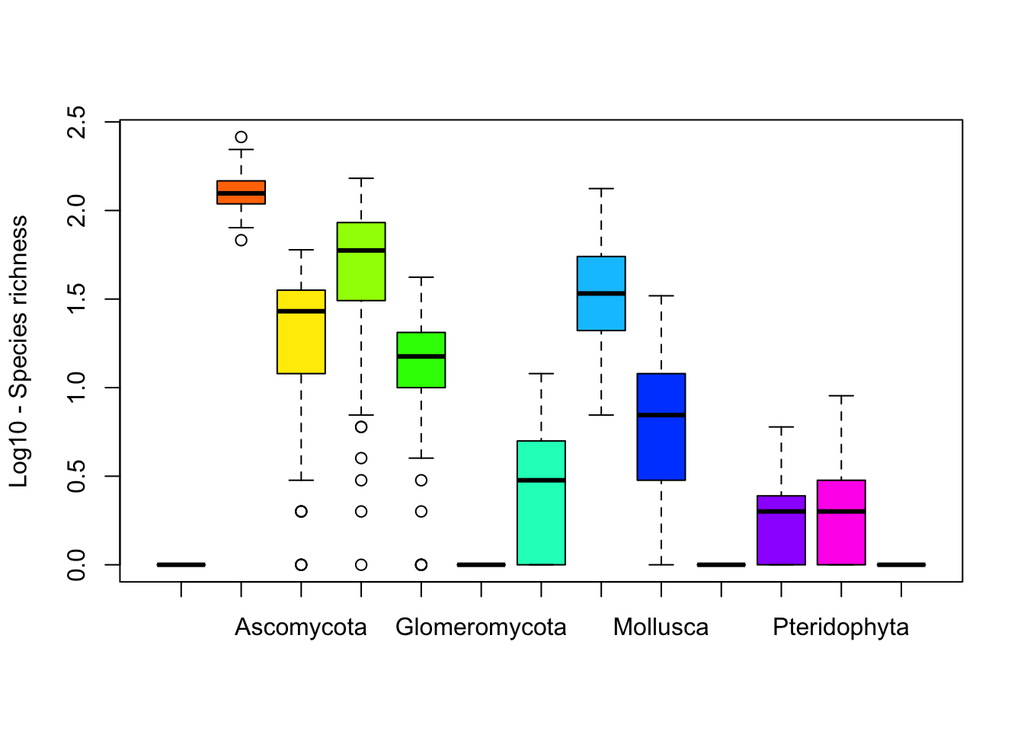

```r
# box-plot of the **Log_10* of species richness.

# Step 1 Count the number of species per site per group
Rich.PerSite <- tapply(X = DK.Biodiv$scientificName,
                            INDEX = list(DK.Biodiv$siteID,DK.Biodiv$phylum),
                            FUN = function(x){length(unique(x))})

# Step 2. Plot the Box-plot of log-10 richness
boxplot(x = log10(Rich.PerSite),
        ylab = "Log10 - Species richness",
        col = rainbow(dim(Rich.PerSite)[2]))
```

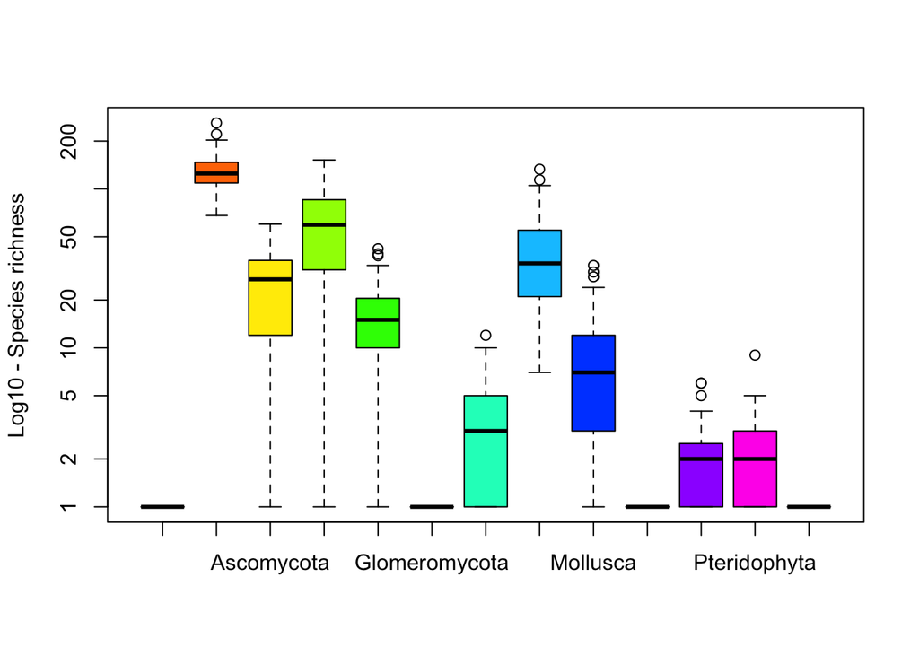

```r
# Plot the Box-plot of log-10 richness Ver 2
boxplot(x = (Rich.PerSite),
        log = "y",
        ylab = "Log10 - Species richness",
        col = rainbow(dim(Rich.PerSite)[2]))
```

**Question:**

- How do you interpret a difference in one (1) unit in Y-axis of the box-plot you just plotted?

The Y-axes is in a logarithmic scale, which means a difference in one means one order of magnitude difference between groups

**Your task:**

Based on the data stored in the object `DK.Biodiv`, you will:

```r
# Estimate the correlation between species richness per site and latitude.

# Step 1 transform Rich.PerSite to a data.frame

Rich.PerSite <- as.data.frame(Rich.PerSite)

# Step 2 Define the latitude to each site
Rich.PerSite$Lat <- do.call("c",lapply(strsplit(row.names(Rich.PerSite),"-"),
       function(x){as.numeric(x[1])}))

# Step 3 Define the Longitude to each site
SiteLon <- do.call("c",lapply(strsplit(row.names(Rich.PerSite),"-"),
       function(x){as.numeric(x[2])}))
Rich.PerSite$Lon <- SiteLon

# Step 4 estimate the correlation between richness and Latitude
apply(X = Rich.PerSite[,c("Magnoliophyta","Pinophyta")],
      MARGIN = 2,
      FUN = function(x){
        cor(x = x,
            y = Rich.PerSite$Lat,
            use = "pairwise.complete.obs")})
```

```
## Magnoliophyta     Pinophyta
##   -0.08850417    0.40449022
```

```r
# Step 5 estimate the correlation between richness and longitude
apply(X = Rich.PerSite[,c("Magnoliophyta","Pinophyta")],
      MARGIN = 2,
      FUN = function(x){
        cor(x = x,
            y = Rich.PerSite$Lon,
            use = "pairwise.complete.obs")})
```

```
## Magnoliophyta     Pinophyta
##     0.1859107    -0.2546065
```

## *3. Creating and working with `SpatialPointsDataFrame`s*

**Your task:**

Based on the data stored in the object `Rich.PerSite`, you will create a `SpatialPointsDataFrame` were each point represents a sampled location. For this you will:

- Copy the data in `Rich.PerSite` into a new object named `BiowideSptPnt`.
- Use the function `coordinates()` to transform `BiowideSptPnt` into a `SpatialPointsDataFrame`.
- Check the class of `BiowideSptPnt`.
- Call the `BiowideSptPnt` object.

```r
# Create a `SpatialPointsDataFrame`
BiowideSptPnt <- Rich.PerSite

#Step 1. Use the function coordinates() to create a SpatialPointsDataFrame.
coordinates(BiowideSptPnt) <- ~Lon+Lat

#Step 2. Check the class of BiowideSptPnt to be sure that is a SpatialPointsDataFrame.
class(BiowideSptPnt)
```

```
## [1] "SpatialPointsDataFrame"
## attr(,"package")
## [1] "sp"
```

```r
#Step 2. Call the BiowideSptPnt object
BiowideSptPnt
```

```
## class       : SpatialPointsDataFrame
## features    : 130
## extent      : 8.080258, 12.53901, 54.71459, 57.64473  (xmin, xmax, ymin, ymax)
## crs         : NA
## variables   : 13
## names       : V1, Arthropoda, Ascomycota, Basidiomycota, Bryophyta, Glomeromycota, Hepatophyta, Magnoliophyta, Mollusca, Nematoda, Pinophyta, Pteridophyta, Zygomycota
## min values  :  1,         68,          1,             1,         1,             1,           1,             7,        1,        1,         1,            1,          1
## max values  :  1,        260,         60,           152,        42,             1,          12,           133,       33,        1,         6,            9,          1
```

**Your task:**

Using the object `BiowideSptPnt`, you will.

- Check the projection of `BiowideSptPnt`.
- Define a Projection for `BiowideSptPnt` using the function `projection()`.
- Visualize the `BiowideSptPnt` object.

```r
# Define a Projection for BiowideSptPnt

#Step 1. Check the projection of BiowideSptPnt
## One way is to use the function `projection()`
projection(BiowideSptPnt)
```

```
## [1] NA
```

```r
## Another way is to Call the object
BiowideSptPnt
```

```
## class       : SpatialPointsDataFrame
## features    : 130
## extent      : 8.080258, 12.53901, 54.71459, 57.64473  (xmin, xmax, ymin, ymax)
## crs         : NA
## variables   : 13
## names       : V1, Arthropoda, Ascomycota, Basidiomycota, Bryophyta, Glomeromycota, Hepatophyta, Magnoliophyta, Mollusca, Nematoda, Pinophyta, Pteridophyta, Zygomycota
## min values  :  1,         68,          1,             1,         1,             1,           1,             7,        1,        1,         1,            1,          1
## max values  :  1,        260,         60,           152,        42,             1,          12,           133,       33,        1,         6,            9,          1
```

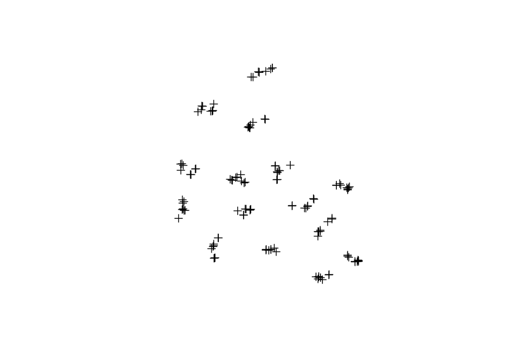

```r
# Step 2. Define the projection
## As the Object has no projection you can just add it as a string
projection(BiowideSptPnt) <- CRS("+proj=longlat +ellps=WGS84 +datum=WGS84 +no_defs")

# Step 3. Visualize the BiowideSptPnt object
plot(BiowideSptPnt)
```

**Your task:**

Based on the data stored in the object `Rich.PerSite`, create a `SpatialPointsDataFrame` were each point represents a sampled location. For this, you will:

- Use the function `SpatialPointsDataFrame()` to transform `Rich.PerSite` into a spatial object named `BiowideSptPnt`.
- Check the class of `BiowideSptPnt`.
- Call and visualize the `BiowideSptPnt` object.

```r
# Step 1. Create a `SpatialPointsDataFrame`
BiowideSptPnt <- SpatialPointsDataFrame(coords = Rich.PerSite[,c("Lon","Lat")],
                                          proj4string = CRS("+proj=longlat +ellps=WGS84 +datum=WGS84 +no_defs"),
                                          data = Rich.PerSite)

# Step 2. Check the class of BiowideSptPnt to be sure that is a SpatialPointsDataFrame.
class(BiowideSptPnt)
```

```
## [1] "SpatialPointsDataFrame"
## attr(,"package")
## [1] "sp"
```

```r
# Step 3a. Call the BiowideSptPnt object
BiowideSptPnt
```

```
## class       : SpatialPointsDataFrame
## features    : 130
## extent      : 8.080258, 12.53901, 54.71459, 57.64473  (xmin, xmax, ymin, ymax)
## crs         : +proj=longlat +datum=WGS84 +no_defs
## variables   : 15
## names       : V1, Arthropoda, Ascomycota, Basidiomycota, Bryophyta, Glomeromycota, Hepatophyta, Magnoliophyta, Mollusca, Nematoda, Pinophyta, Pteridophyta, Zygomycota,         Lat,         Lon
## min values  :  1,         68,          1,             1,         1,             1,           1,             7,        1,        1,         1,            1,          1, 54.71459402, 8.080258493
## max values  :  1,        260,         60,           152,        42,             1,          12,           133,       33,        1,         6,            9,          1, 57.64472818, 12.53900706
```

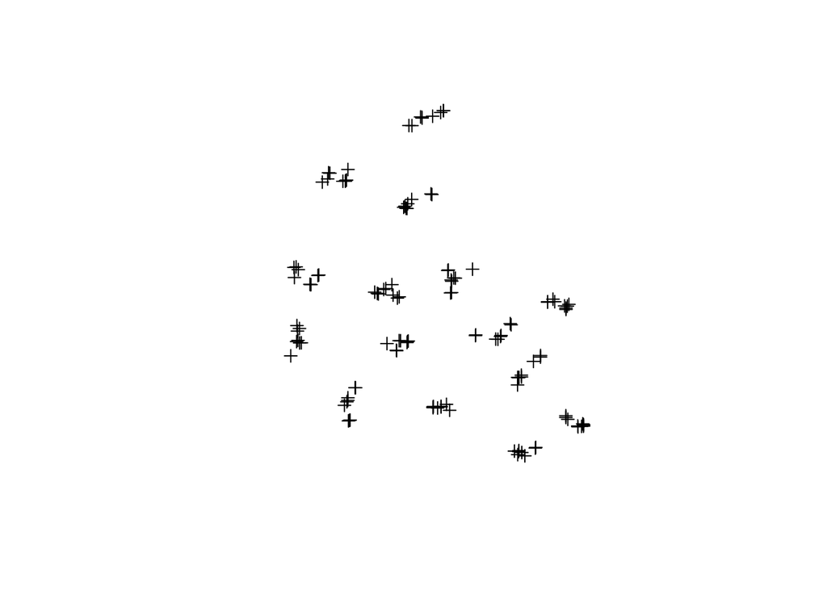

```r
# Step 3b. Visualize the BiowideSptPnt object
plot(BiowideSptPnt)
```

**Question:**

- What is the diff between the the `SpatialPointsDataFrame` created with the function `coordinates()` and the one created using the `SpatialPointsDataFrame()` function?

The object created with *`coordinates()`* removes the coordinates from the data (it only has 13 variables), while the object created with `SpatialPointsDataFrame()` has all the data included in the `Rich.PerSite` object.

**Your task:**

Based on the data stored in the object `BiowideSptPnt`, you will.

- Re-project this object to the projection system for Denmark (UTM/ETRS89).
- Call and visualize `BiowideSptPnt.UTM`.

```r
# Step 1. Re-project BiowideSptPnt to UTM/ETRS89
BiowideSptPnt.UTM <- spTransform(x = BiowideSptPnt,
                                 CRSobj = CRS("+proj=utm +zone=32 +ellps=GRS80 +units=m +no_def"))
# Step 2a. Call BiowideSptPnt.UTM
BiowideSptPnt.UTM
```

```
## class       : SpatialPointsDataFrame
## features    : 130
## extent      : 441993, 726525, 6066245, 6390025  (xmin, xmax, ymin, ymax)
## crs         : +proj=utm +zone=32 +ellps=GRS80 +units=m +no_defs
## variables   : 15
## names       : V1, Arthropoda, Ascomycota, Basidiomycota, Bryophyta, Glomeromycota, Hepatophyta, Magnoliophyta, Mollusca, Nematoda, Pinophyta, Pteridophyta, Zygomycota,         Lat,         Lon
## min values  :  1,         68,          1,             1,         1,             1,           1,             7,        1,        1,         1,            1,          1, 54.71459402, 8.080258493
## max values  :  1,        260,         60,           152,        42,             1,          12,           133,       33,        1,         6,            9,          1, 57.64472818, 12.53900706
```

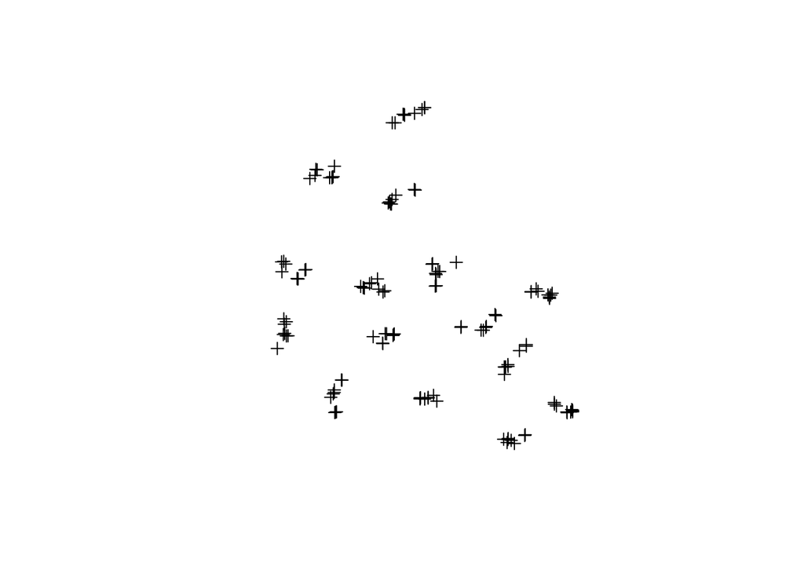

```r
# Step 2b. plot BiowideSptPnt.UTM
plot(BiowideSptPnt.UTM)
```

## *4. Creating and working with `SpatialPolygonsDataFrame`s*

**Your task:** Here you will get data from an on-line repository. For this. you will:

- Use the function `getData()` to get the first level of administrative subdivision for Denmark (i.e., landsdele). Store the data in an object named `LandsdeleShp`.
- Visualize `LandsdeleShp`.

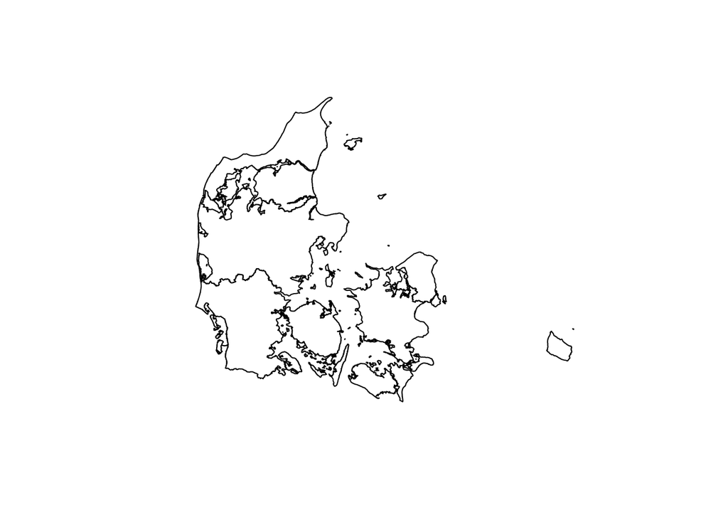

```r
# Step 1. Get The level-1 map for Denmark - Denmark/ISO-code is DNK
LandsdeleShp <- getData(name = 'GADM',
                        country= 'DNK',
                        level=1,
                        path = "Data/")
# Step 2. Visualize LandsdeleShp
plot(LandsdeleShp)
```

**Question:**

- Can you use the object `BiowideSptPnt.UTM` to extract the names of the regions of Denmark in `LandsdeleShp` for each sampled location?

NO, The reasons is that the object `LandsdeleShp` is geo-referenced, while `BiowideSptPnt.UTM` is projected to UTM-coordinates.

**Your task:** Based on the data stored in the object `LandsdeleShp`, you will.

- Call the projection of `LandsdeleShp`.
- Re-project this object to the projection system for Denmark (UTM/ETRS89). For this, use the function `spTransform()`.
- Call and plot `LandsdeleShp.UTM`.

```r
# Step 1. check the projection of LandsdeleShp
projection(LandsdeleShp)
```

```
## [1] "+proj=longlat +datum=WGS84 +no_defs"
```

```r
# Step 2. Re-project LandsdeleShp to UTM/ETRS89
LandsdeleShp.UTM <- spTransform(x = LandsdeleShp,
                                 CRSobj = CRS("+proj=utm +zone=32 +ellps=GRS80 +units=m +no_def"))
# Step 3a. Call LandsdeleShp.UTM to check the projection of LandsdeleShp.UTM
LandsdeleShp.UTM@data
```

```
##   GID_0  NAME_0   GID_1      NAME_1       VARNAME_1 NL_NAME_1 TYPE_1 ENGTYPE_1
## 1   DNK Denmark DNK.1_1 Hovedstaden         Capital      <NA> Region    Region
## 2   DNK Denmark DNK.2_1 Midtjylland Central Jutland      <NA> Region    Region
## 3   DNK Denmark DNK.3_1 Nordjylland   North Jutland      <NA> Region    Region
## 4   DNK Denmark DNK.4_1    Sjælland         Zealand      <NA> Region    Region
## 5   DNK Denmark DNK.5_1  Syddanmark   South Denmark      <NA> Region    Region
##   CC_1 HASC_1
## 1 <NA>  DK.HS
## 2 <NA>  DK.MJ
## 3 <NA>  DK.ND
## 4 <NA>  DK.SL
## 5 <NA>  DK.SD
```

```r
# Step 3b. Plot LandsdeleShp.UTM
LandsdeleShp.UTM@data
```

[output not shown]

```
##   GID_0  NAME_0   GID_1      NAME_1       VARNAME_1 NL_NAME_1 TYPE_1 ENGTYPE_1
## 1   DNK Denmark DNK.1_1 Hovedstaden         Capital      <NA> Region    Region
## 2   DNK Denmark DNK.2_1 Midtjylland Central Jutland      <NA> Region    Region
## 3   DNK Denmark DNK.3_1 Nordjylland   North Jutland      <NA> Region    Region
## 4   DNK Denmark DNK.4_1    Sjælland         Zealand      <NA> Region    Region
## 5   DNK Denmark DNK.5_1  Syddanmark   South Denmark      <NA> Region    Region
##   CC_1 HASC_1
## 1 <NA>  DK.HS
## 2 <NA>  DK.MJ
## 3 <NA>  DK.ND
## 4 <NA>  DK.SL
## 5 <NA>  DK.SD
```

**Your task:** Using the `BiowideSptPnt.UTM` and `LandsdeleShp.UTM` objects, you will.

- Call the data included in `LandsdeleShp.UTM`.
- Extract the region of Denmark (Landsdele) where each variable was sampled. For this you will use the function `over()`.
- Add this information to `BiowideSptPnt.UTM` as a new variable named *landsdele*.
- Check the data in `BiowideSptPnt.UTM` by calling the first five rows.

```r
# Step 1. Call the data included in LandsdeleShp.UTM
LandsdeleShp.UTM@data
```

```
##   GID_0  NAME_0   GID_1      NAME_1       VARNAME_1 NL_NAME_1 TYPE_1 ENGTYPE_1
## 1   DNK Denmark DNK.1_1 Hovedstaden         Capital      <NA> Region    Region
## 2   DNK Denmark DNK.2_1 Midtjylland Central Jutland      <NA> Region    Region
## 3   DNK Denmark DNK.3_1 Nordjylland   North Jutland      <NA> Region    Region
## 4   DNK Denmark DNK.4_1    Sjælland         Zealand      <NA> Region    Region
## 5   DNK Denmark DNK.5_1  Syddanmark   South Denmark      <NA> Region    Region
##   CC_1 HASC_1
## 1 <NA>  DK.HS
## 2 <NA>  DK.MJ
## 3 <NA>  DK.ND
## 4 <NA>  DK.SL
## 5 <NA>  DK.SD
```

```r
# Step 2. Extract the region name that corresponds to each sampled point using the function over.
landsdele <- over(x = BiowideSptPnt.UTM, # The SpatialPointDataFrame
                  y = LandsdeleShp.UTM["NAME_1"] # The attribute to extract
)

# Step 3. add this variable to BiowideSptPnt.UTM
BiowideSptPnt.UTM$landsdele <- as.vector(landsdele[,1])

# Step 3. Check the data in BiowideSptPnt.UTM by Calling the first five rows
head(BiowideSptPnt.UTM)
```

```
##                         V1 Arthropoda Ascomycota Basidiomycota Bryophyta
## 54.71459402-11.64563069 NA        260         28            68        15
## 54.72483425-11.53711191 NA        137         55           101        33
## 54.74269892-11.59917006 NA        164          1            22         1
## 54.75036513-11.55167321 NA        141         38            78        22
## 54.75457898-11.48720906 NA        126         NA             3         1
## 54.75928616-11.55493636 NA        133         40           108        15
##                         Glomeromycota Hepatophyta Magnoliophyta Mollusca
## 54.71459402-11.64563069            NA          NA            73       12
## 54.72483425-11.53711191            NA           3            47       16
## 54.74269892-11.59917006            NA          NA            49        5
## 54.75036513-11.55167321            NA           4            25       15
## 54.75457898-11.48720906            NA          NA            26        1
## 54.75928616-11.55493636            NA           1            26       20
##                         Nematoda Pinophyta Pteridophyta Zygomycota      Lat
## 54.71459402-11.64563069       NA        NA            3         NA 54.71459
## 54.72483425-11.53711191       NA        NA            4         NA 54.72483
## 54.74269892-11.59917006       NA        NA            1         NA 54.74270
## 54.75036513-11.55167321       NA        NA            1         NA 54.75037
## 54.75457898-11.48720906       NA        NA           NA         NA 54.75458
## 54.75928616-11.55493636       NA        NA            1         NA 54.75929
##                              Lon landsdele
## 54.71459402-11.64563069 11.64563  Sjælland
## 54.72483425-11.53711191 11.53711  Sjælland
## 54.74269892-11.59917006 11.59917  Sjælland
## 54.75036513-11.55167321 11.55167  Sjælland
## 54.75457898-11.48720906 11.48721  Sjælland
## 54.75928616-11.55493636 11.55494  Sjælland
```

**Your task:** Using the `BiowideSptPnt.UTM` and `LandsdeleShp.UTM` objects, you will.

- Estimate the number of sampled sites per region and save this summary as an object named `SmpSitPerReg`.
- Add the values in `SmpSitPerReg` to`LandsdeleShp.UTM` a new variable that corresponds to the number of sampled sites per region. Name this new variable *NoSampSites*.
- Call the data included in `LandsdeleShp.UTM`.

```r
# Step 1. Estimate the number of sampled sites per region.
SmpSitPerReg <- table(BiowideSptPnt.UTM$landsdele)

# Step 2b. add this variable to LandsdeleShp.UTM
LandsdeleShp.UTM$NoSampSites <- SmpSitPerReg

# Step 3. Check the data in LandsdeleShp.UTM
LandsdeleShp.UTM@data
```

```
##   GID_0  NAME_0   GID_1      NAME_1       VARNAME_1 NL_NAME_1 TYPE_1 ENGTYPE_1
## 1   DNK Denmark DNK.1_1 Hovedstaden         Capital      <NA> Region    Region
## 2   DNK Denmark DNK.2_1 Midtjylland Central Jutland      <NA> Region    Region
## 3   DNK Denmark DNK.3_1 Nordjylland   North Jutland      <NA> Region    Region
## 4   DNK Denmark DNK.4_1    Sjælland         Zealand      <NA> Region    Region
## 5   DNK Denmark DNK.5_1  Syddanmark   South Denmark      <NA> Region    Region
##   CC_1 HASC_1 NoSampSites
## 1 <NA>  DK.HS           9
## 2 <NA>  DK.MJ          33
## 3 <NA>  DK.ND          25
## 4 <NA>  DK.SL          35
## 5 <NA>  DK.SD          27
```

**Your task:** Using the `BiowideSptPnt.UTM` and `LandsdeleShp.UTM` objects, you will.

- Plot`LandsdeleShp.UTM` colouring the Regions (landsdele) by the number of sampling sites.
- Add a legend can be used to interpret the colours representing the number of sampled sites. Use the function `legend()` for this.
- Estimate the richness of vascular plants per site by adding the richness of *Magnoliophyta* & *Pinophyta*.
- Overlay on top of this map `BiowideSptPnt.UTM` sizing the points by the richness of vascular plants.
- Add a legend that can be used to interpret the species richness per site.

[output not shown]

## *5. Rasters-1: Reclassify and aggregate a ‘raster’ object*

**Your task:** Load the data in *BASEMAP_2018_Crop.tif*, the file is the folder associated to the project to the session - see the files tab in your R-studio session.

- Use `raster()` to load the file.
- Save the object as `BASEMAP.Crop`.
- Visualize the object.

```r
# Step 1. Load BASEMAP_2018_Crop.tif
BASEMAP.Crop <- raster("Data/BASEMAP_2018_Crop.tif")
# Step 2. Call the BASEMAP.Crop object
BASEMAP.Crop
```

```
## class      : RasterLayer
## dimensions : 2475, 2684, 6642900  (nrow, ncol, ncell)
## resolution : 10, 10  (x, y)
## extent     : 570560, 597400, 6215380, 6240130  (xmin, xmax, ymin, ymax)
## crs        : +proj=utm +zone=32 +ellps=GRS80 +units=m +no_defs
## source     : BASEMAP_2018_Crop.tif
## names      : BASEMAP_2018_Crop
## values     : 110000, 8e+05  (min, max)
```

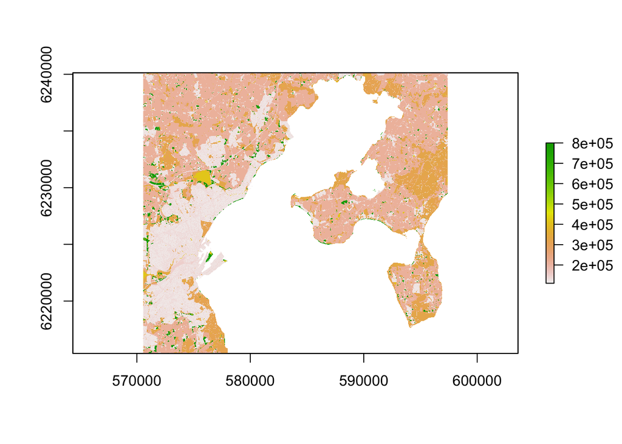

```r
# Step 3. visualize the BASEMAP.Crop object
plot(BASEMAP.Crop)
```

**Question:**

- What is the projection of `BASEMAP.Crop`?

`BASEMAP.Crop` is in the UTM/ETRS89 projection

**Your task:** Using the object `BASEMAP.Crop` you will:

- Load the *Basemap-Legend.csv* file with the link between codes in `BASEMAP.Crop`and the land cover classes names.The file is in the folder associated to the project to the session.
- Extract the Data in `BASEMAP.Crop` and save it as a object named `BASEMAP.Data`.
- Transform `BASEMAP.Data` to a factor using the data in `BASEMAP.Legend`.
- Estimate the number of cells per Land cover class. Use the function `table()` to do this.

```r
# Step 1. Load Basemap-Legend.csv
BASEMAP.Legend <- read.csv("Data/Basemap-Legend.csv")

# Step 2. Extract the Data in BASEMAP.Crop and save it as a object named BASEMAP.Data
BASEMAP.Data <- values(BASEMAP.Crop)

# Step 3. Transform BASEMAP.Data to a factor using the data in BASEMAP.Legend to define the levels and labels
BASEMAP.Data.Factor <- factor(x = BASEMAP.Data,
                              levels = BASEMAP.Legend$Code,
                              labels = BASEMAP.Legend$Name)
# Step 4. Use the function table to count the number of cells per land cover type defined in BASEMAP.Data.Factor - Call the object
CountLandCov <- table(BASEMAP.Data.Factor)

# Step 5. Sort the data in CountLandCov in increasing order
sort(CountLandCov)
```

```
## BASEMAP.Data.Factor
##                          Airport/runway                Airport/runway; Building
##                                       0                                       0
##                     Resource extraction                                     Sea
##                                       0                                       0
##                                Unmapped                       Railway; Building
##                                       0                                     584
##                Other built up; Building                                Building
##                                    1073                                    1839
##                             Forest, wet Recreation area/sports ground; Building
##                                    2876                                    4142
##                             City centre                   City centre; Building
##                                    7319                                    8172
##                          Other built up                                  Stream
##                                    9225                                   10663
## Agriculture, intensive, permanent crops                 High built up; Building
##                                   10776                                   14038
##                                 Railway             Agriculture, not classified
##                                   15004                                   21599
##             Industry/business; Building                           High built up
##                                   29913                                   35410
##                                    Lake                             Nature, wet
##                                   35566                                   46488
##                             Nature, dry                         Road, not paved
##                                   54514                                   55344
##     Nature, wet; Agriculture, extensive                       Industry/business
##                                   63881                                   68563
##                  Low built up; Building           Recreation area/sports ground
##                                  100437                                  102381
##     Nature, dry; Agriculture, extensive                  Agriculture, extensive
##                                  104083                                  170346
##                             Road, paved                                  Forest
##                                  279708                                  363935
##                            Low built up Agriculture, intensive, temporary crops
##                                  365562                                 1462387
```

**Questions:**

- Which land Cover type is the most abundant?
- Which land Cover type(s) are not represented?
- What is the coverage of Forested areas?

Agriculture, intensive, temporary crops is the most abundant land cover type. Airport/runway, Resource extraction, Sea, and Unmapped are not represented in the map. Forested areas (Fortes + Forest,Wet) cover an area of 36.6811km2 (the sum of the number of cells x the area of each cell (100m2) x the conversion factor from m2 to km2)

**Your task:** Using the object `BASEMAP.Crop` and the data in `BASEMAP.Legend` you will reclassify ``BASEMAP.Crop` so that it shows areas consider as Agricultural areas (Agriculture-intensive/extensive-temporary crops/permanent crops). For this, you will:

- Create a new table that transform the *Names* variable in `BASEMAP.Legend` to 1 (Agricultural areas) and 0 (Other areas). Name this new table `Reclas.Table`.
- Transform `Reclas.Table` into a matrix. Use the function `as.matrix()`.
- Reclassify `BASEMAP.Crop` using `Reclas.Table` so that only only shows the cells considered as Agricultural areas. For this, use the function `reclassify()`. Store the reclassified map as an object named `BASEMAP.Agri`.
- Plot `BASEMAP.Agri`.

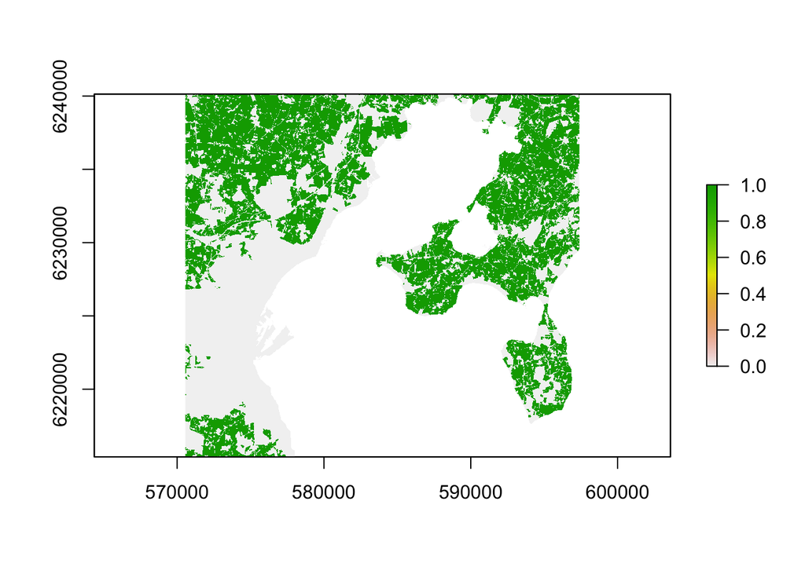

```r
# Step 1. Create a reclassification table (Reclas.Table) using the data in BASEMAP.Legend
Reclas.Table <- BASEMAP.Legend
Reclas.Table$Name <- 0
Reclas.Table$Name[grep("Agriculture",BASEMAP.Legend$Name)] <- 1
Reclas.Table <- rbind(Reclas.Table,c(NA,NA))
# Step 2. Transform Reclas.Table into a matrix
Reclas.Table <- as.matrix(Reclas.Table)
# Step 3. Use the reclassify function to transform BASEMAP.Crop into a binary map (BASEMAP.Agri) based on Reclas.Table
BASEMAP.Agri <- reclassify(x = BASEMAP.Crop,
                          rcl = Reclas.Table)
# Step 3. plot BASEMAP.Agri
plot(BASEMAP.Agri)
```

**Your task:** Using the object `BASEMAP.Agri` you will:

- Estimate the Agricultural Density per 1km^2 using the function `aggregate()`. save the aggregated raster as an object named `BASEMAP.Agri`.
- Plot `BASEMAP.Agri`.

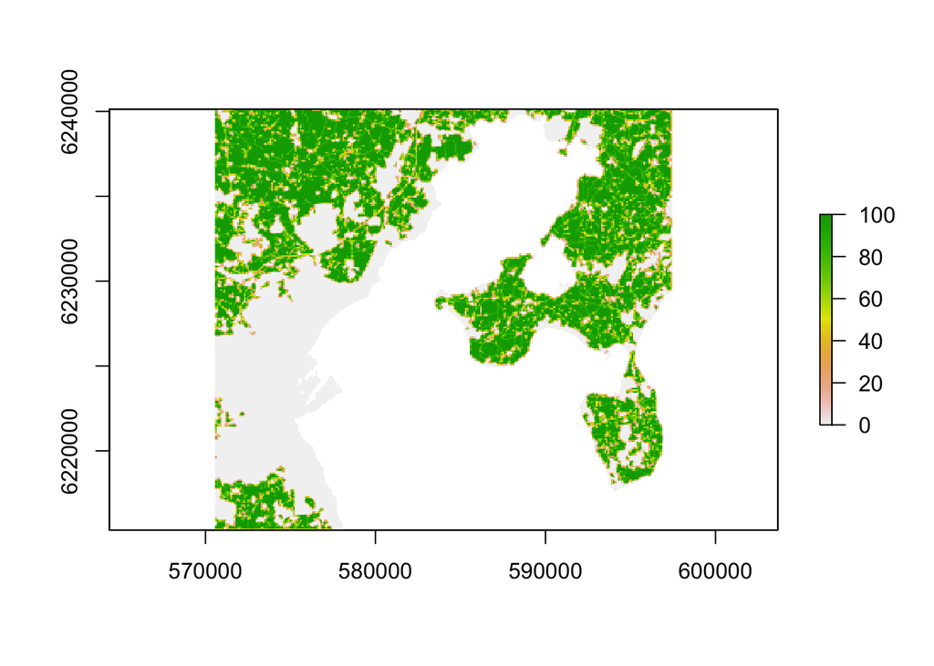

```r
# Step 1. Aggregate the raster `BASEMAP.Agri`. Save the result as an object named AgriDen
AgriDen <- aggregate(x = BASEMAP.Agri,
                     fact = 10,
                     fun = sum,
                     na.rm = T)
# Step 2. Plot the AgriDen object to visualize the result
plot(AgriDen)
```

**Your task:** Load the data in *NatDens_BaseMap.tif* that has the density of natural areas based on BASEMAP. The file is the folder associated to the project to the session - see the files tab in your R-studio session.

- Use `raster()` to load the file.
- Save the object as `NatDens.DK`.
- Call the object to check it’s properties.
- Visualize the object.

```r
# Step 1. Load NatDens_BaseMap.tif
NatDens.DK <- raster("Data/NatDens_BaseMap.tif")

# Step 2. Call the NatDens.DK object
NatDens.DK
```

```
## class      : RasterLayer
## dimensions : 369, 460, 169740  (nrow, ncol, ncell)
## resolution : 1000, 1000  (x, y)
## extent     : 433390, 893390, 6038850, 6407850  (xmin, xmax, ymin, ymax)
## crs        : +proj=utm +zone=32 +ellps=GRS80 +units=m +no_defs
## source     : NatDens_BaseMap.tif
## names      : NatDens_BaseMap
## values     : 0, 1  (min, max)
```

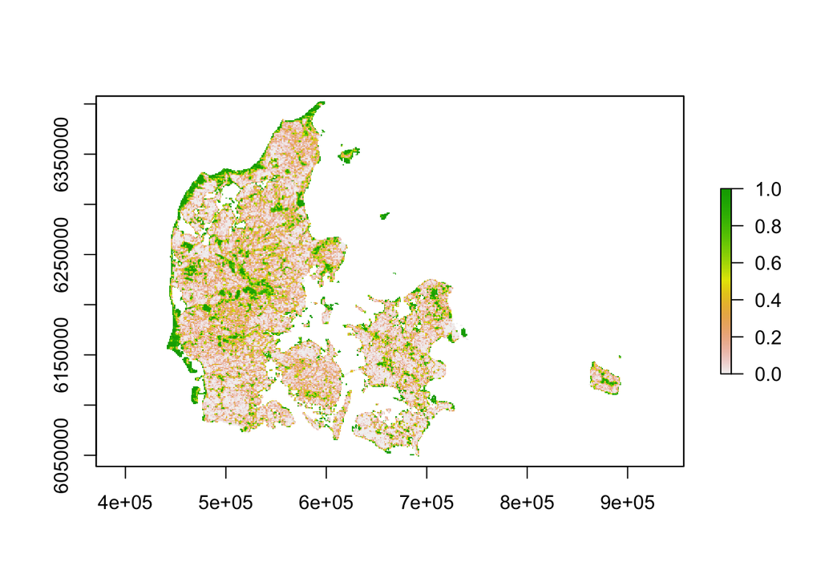

```r
# Step 3. visualize the NatDens.DK object
plot(NatDens.DK)
```

**Questions:**

- What is the projection of the `NatDens.DK` raster?
- Can you use the object `BiowideSptPnt` to extract the values of Nature Density from `NatDens.DK`.

The `NatDens.DK` object is projected to Denmark's projection system (UTM/ETRS89). By comparison `BiowideSptPnt` is only referenced, so it **CAN NOT** be used to extract the information in `NatDens.DK`. You need to use `BiowideSptPnt.UTM` for this.

**Your task:** Extract the information in `NatDens.DK` using the appropriate Biowide `StaialPointsDataFrame` object. For this, you will:

- Use the function `extract ()`.
- Save the data as a new variable named *NatDens* in the appropriate Biowide `StaialPointsDataFrame` object.
- Plot a histogram for *NatDens*.

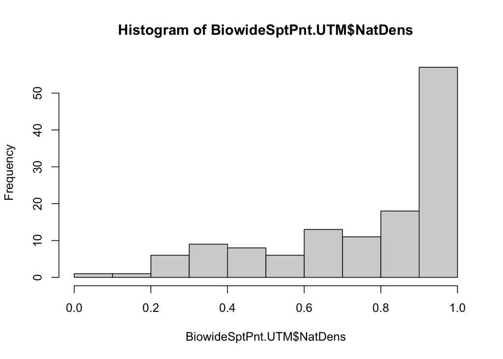

```r
#Step 1. Extract the data in NatDens.DK & save it to the appropriate SpatialPoints object
BiowideSptPnt.UTM$NatDens <- extract(x = NatDens.DK,
                                     y = BiowideSptPnt.UTM)

#Step 2. Plot a histogram for *NatDens*
hist(BiowideSptPnt.UTM$NatDens)
```

**Your task:** Based on the information in `BASEMAP.Crop` and `BASEMAP.Legend` you will plot the land cover raster as a categorical raster. For this, you will:

- Transform `BASEMAP.Crop` into a factor using the function `ratify()`. Store the transformed `BASEMAP.Crop` as an object names `BASEMAP.Crop.Fact`.
- Extract the levels in the `BASEMAP.Crop.Fact` categorical raster using the function `levels()`. Store these levels as an object named `rat`.
- Add an extra attribute to `rat` that will be used for the legend. This is done by matching the values in `rat` to the `code` variable in `BASEMAP.Legend`, and extracting from `BASEMAP.Legend` the variable `Name`. use the function `match()` for this.
- Make now `rat` the `leves` of `BASEMAP.Crop.Fact` using the function `levels()`.
- Plot `BASEMAP.Crop.Fact` using the function `levelplot()` from the `rasterVis` package.

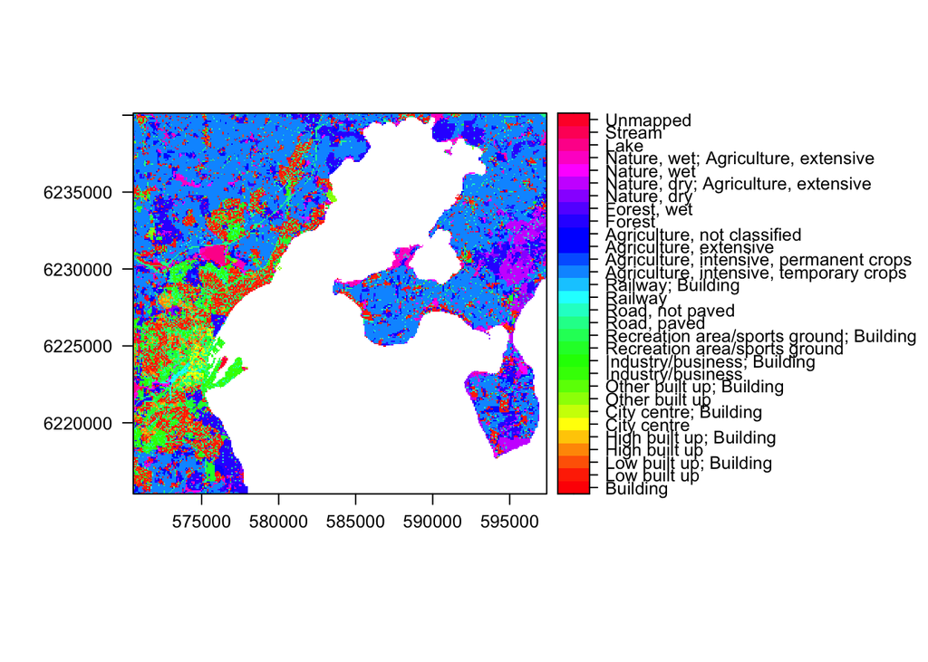

```r
# Step 1. Transform `NatDens.DK` into a factor
BASEMAP.Crop.Fact <- ratify(BASEMAP.Crop)

# Step 2. Extract the Factors - note that you will get a list with one slot.
rat <- levels(BASEMAP.Crop.Fact)

# Step 3. Add the Name for each factors using the information in `BASEMAP.Legend`
rat[[1]][,'landcover'] <- BASEMAP.Legend[match(rat[[1]][,1],BASEMAP.Legend[,1]),2]

# Step 4. Make rat the levels in BASEMAP.Crop.Fact
levels(BASEMAP.Crop.Fact) <- rat

# Step 4. Plot BASEMAP.Crop.Fact
levelplot(x = BASEMAP.Crop.Fact,
          col.regions = rainbow(dim(rat[[1]])[1]))
```

## *5. Rasters-3: Map Algebra*

**Your task:** Load the data in *Tmean_CHELSA-DK.tif*, the file is the folder associated to the project to the session - see the files tab in your R-studio session.

- Use `stack()` to load the file.
- Save the object as `Tmean.DK`.
- Visualize the object.

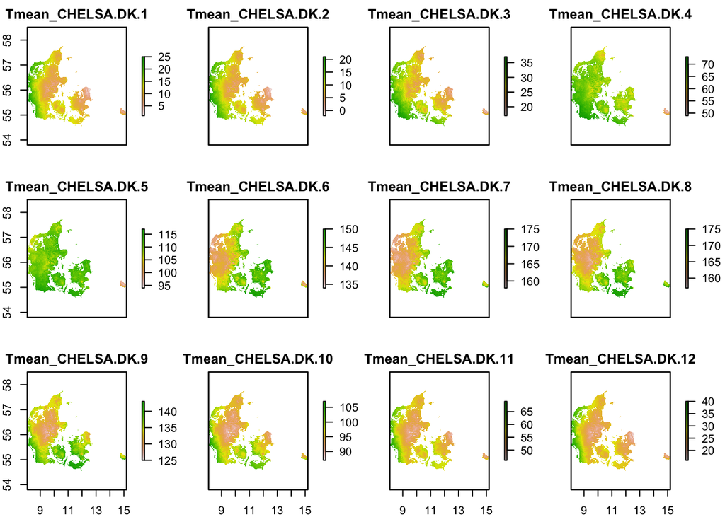

```r
# Step 1. Load Tmean_CHELSA-DK.tif and store it as an object named Tmean.DK
Tmean.DK <- stack("Data/Tmean_CHELSA-DK.tif")

# Step 2. Visualize the object.
plot(Tmean.DK)
```

**Question:**

- What is the difference between loading the data using the functions `raster()`, `stack()`, and `brick()`

The difference between `raster()` and `stack()`/`brick()` is that `raster()` ONLY loads one of the layers in the raster. Both `stack()`and `brick()` can load multiple layers of multi band rasters, or store multiple individual rates ans a multi-band raster object. The difference between `stack()`and `brick()` is that in **stacks** all data is in the same locations, while for **brick** it can be in multiple locations.

**Your task:** Using the data in `Tmean.DK` yo will now estimate the annual Temperature seasonality as:

- The standard deviation of mean monthly temperatures. Store this operation as an object named `TSes.SD`. Use the function `calc()` for this.
- The coefficient of variation of mean monthly temperatures. Store this operation as an object named `TSes.CV`. Use the function `calc()` for this.
- Stack `TSes.SD` and `TSes.CV` as an object named `TSes.DK`. Use the function `stack()` for this.
- Visualize `TSes.DK`.

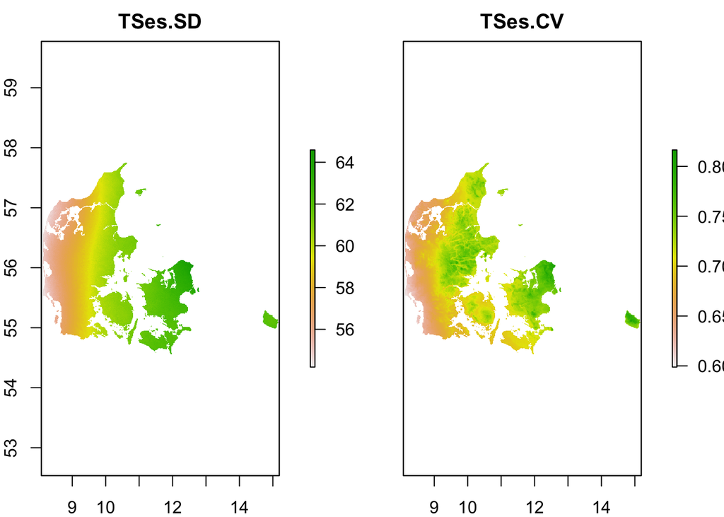

```r
# Step 1. Estimate the annual Temperature seasonality as SD
TSes.SD <- calc(Tmean.DK,
                fun = function(x){sd(x,na.rm = T)})

# Step 2. Estimate the annual Temperature seasonality as CV
TSes.CV <- calc(Tmean.DK,
                fun = function(x){sd(x,na.rm = T)/mean(x,na.rm = T)})

# Step 3. Stack `TSes.SD` and `TSes.CV`
TSes.DK <- stack(TSes.SD, TSes.CV)
names(TSes.DK)<- c("TSes.SD","TSes.CV")
# Step 4. Visualize `TSes`.
plot(TSes.DK)
```

**Questions:**

- What is the projection of the `TSes.DK` raster?
- Can you use the object `BiowideSptPnt.UTM` to extract the values of Nature Density from `NatDens.DK`.

The `TSes.DK` object is referenced, so you CANNOT use `BiowideSptPnt.UTM` to extract the information in `TSes.DK` as `BiowideSptPnt.UTM` is projected to Denmark's projection system (UTM/ETRS89).

**Your task:** Using the object `TSes.DK` you will:

- Re-project the raster to Denmark’s projection system (UTM/ETRS89). For this, use the function `projectRaster()`.
- Store the Re-projected raster as an object named `TSes.DK.UTM`
- Call the `TSes.DK.UTM` to check the projection.

```r
# Step 1. Re-project the raster
TSes.DK.UTM <- projectRaster(from = TSes.DK,
                             crs = CRS("+proj=utm +zone=32 +ellps=GRS80 +units=m +no_defs"))
# Step 2. Call the Re-projected raster
TSes.DK.UTM
```

```
## class      : RasterBrick
## dimensions : 411, 908, 373188, 2  (nrow, ncol, ncell, nlayers)
## resolution : 517, 927  (x, y)
## extent     : 435519.5, 904955.5, 6041352, 6422349  (xmin, xmax, ymin, ymax)
## crs        : +proj=utm +zone=32 +ellps=GRS80 +units=m +no_defs
## source     : memory
## names      :    TSes.SD,    TSes.CV
## min values : 54.1943659,  0.5988493
## max values : 64.5433258,  0.8134515
```

**Your task:** Using the objects `TSes.DK` and `BiowideSptPnt.UTM` you will:

- Extract both the Temperature seasonality estimated using the standard deviation for all sampled locations.
- Save the data as a new variable named *TSes* in `BiowideSptPnt.UTM`.
- Visualize the extracted data as a box-plot grouping *TSes* by *regions*.

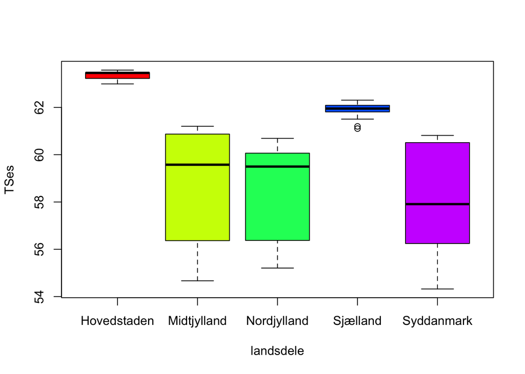

```r
# Step 1. Extract both the SD derived Temperature seasonality
BiowideSptPnt.UTM$TSes <- extract(x = TSes.DK.UTM[["TSes.SD"]],
                                  y = BiowideSptPnt.UTM)

TSes.DK.UTM <- projectRaster(from = TSes.DK,
                             crs = CRS("+proj=utm +zone=32 +ellps=GRS80 +units=m +no_defs"))

# Step 2. Visualize TSes as a box-plot
boxplot(formula = TSes ~ landsdele,
        data = BiowideSptPnt.UTM,
        col = rainbow(5))
```